# Yogurt & the Vaginal Microbiome After Antibiotics — Group Report

> A workshop project analysing how yogurt consumption affects the vaginal microbiome in women taking antibiotics.

```r
library(tidyverse)
library(here)
library(gtsummary)
library(ggpubr)

# ── Read all 4 data files ──────────────────────────────────────────
samples  <- read_csv(here("data/group_a_yogurt/00_sample_ids_yogurt.csv"))
metadata <- read_csv(
  here("data/group_a_yogurt/01_participant_metadata_yogurt.csv"),
  col_types = cols(sex = col_character())
)
qpcr     <- read_csv(here("data/group_a_yogurt/02_qpcr_results_yogurt.csv"))
luminex  <- read_csv(here("data/group_a_yogurt/03_luminex_results_yogurt.csv"))
```

## Q1 — Which variable defines the groups you want to compare?

```r
# The grouping variable is `arm`
metadata |>
  count(arm)
```

```
# A tibble: 2 × 2
  arm                n
  <chr>          <int>
1 unchanged_diet    25
2 yogurt            26
```

**Answer:** The variable **`arm`** defines the groups. It has two levels:

| Value | Meaning | N |
| --- | --- | --- |
| `yogurt` | Ate yogurt daily after antibiotics | 26 |
| `unchanged_diet` | Kept usual diet (control) | 25 |

Every comparison in this report is **yogurt vs. unchanged_diet** at the “after_antibiotic” time point (or baseline → after change).

## Q2 — Which demographic and baseline variables belong in your Table 1?

**Answer:** The variables that describe participants *before* the intervention and could potentially differ between arms (even with randomisation):

| Variable | Type | Why it goes in Table 1 |
| --- | --- | --- |
| `age` | Continuous | Could affect immune response and microbiome |
| `education` | Categorical | Proxy for socioeconomic factors |
| `birth_control` | Categorical | Hormonal BC affects the vaginal microbiome |
| `days_since_last_sex` | Continuous | Recent sex can temporarily alter the microbiome |
| `sex` | Constant | All female — skip it |
| `pid` | ID | Not a variable — skip it |

### Table 1

```r
# ── Table 1 ────────────────────────────────────────────────────────
metadata |>
  select(-pid, -sex) |>
  tbl_summary(
    by = arm,
    statistic = list(age ~ "{mean} ({sd})")
  ) |>
  add_p(
    test = list(age ~ "t.test")
  ) |>
  add_overall() |>
  bold_labels() |>
  modify_header(label ~ "**Characteristic**")
```

| **Characteristic** | **Overall** N = 51<sup>1</sup> | **unchanged_diet** N = 25<sup>1</sup> | **yogurt** N = 26<sup>1</sup> | **p-value**<sup>2</sup> |
| --- | --- | --- | --- | --- |
| days_since_last_sex | 5 (3, 11) | 6 (3, 10) | 5 (3, 11) | 0.8 |
| birth_control |  |  |  | 0.017 |
| Depoprovera | 25 (49%) | 8 (32%) | 17 (65%) |  |
| no hormonal birth control | 26 (51%) | 17 (68%) | 9 (35%) |  |
| age | 30.7 (3.3) | 30.4 (3.3) | 31.0 (3.3) | 0.5 |
| education |  |  |  | 0.8 |
| grade 10-12, matriculated | 10 (20%) | 6 (24%) | 4 (15%) |  |
| grade 10-12, not matriculated | 21 (41%) | 9 (36%) | 12 (46%) |  |
| less than grade 9 | 9 (18%) | 4 (16%) | 5 (19%) |  |
| post-secondary | 11 (22%) | 6 (24%) | 5 (19%) |  |

<sup>1</sup> Median (Q1, Q3); n (%); Mean (SD)  
<sup>2</sup> Wilcoxon rank sum test; Pearson’s Chi-squared test; Welch Two Sample t-test; Fisher’s exact test

**Interpretation:**

- **Age, education, days_since_last_sex** — well balanced (p > 0.05). The randomisation did its job for these.
- **birth_control** — imbalanced (p = 0.017). The yogurt arm has twice as many Depoprovera users (65% vs 32%). This is worth noting because hormonal contraception can affect vaginal *Lactobacillus* levels. If we see a difference between arms in the outcomes, we may need to check whether birth control is driving it, not the yogurt.

## Q3 — Which outcome variables are most relevant to your question?

**Original question:** *How does yogurt affect the vaginal microbiome in response to antibiotics?*

```r
# ── What qPCR outcomes are available ───────────────────────────────
qpcr |>
  select(-sample_id) |>
  names()
```

```
[1] "qpcr_bacteria"  "qpcr_crispatus" "qpcr_iners"
```

```r
# ── What cytokines are available ───────────────────────────────────
luminex |>
  distinct(cytokine) |>
  pull(cytokine)
```

```
 [1] "IL-1a"  "IL-10"  "IL-1b"  "IL-8"   "IL-6"   "TNFa"   "IP-10"  "MIG"
 [9] "IFN-Y"  "MIP-3a"
```

**Answer:**

| Outcome | Data source | What it measures | Relevance |
| --- | --- | --- | --- |
| `qpcr_crispatus` | qPCR | *L. crispatus* — the “gold standard” protective species | **High** — should increase if yogurt helps |
| `qpcr_iners` | qPCR | *L. iners* — a less stable species, marker of dysbiosis | **High** — should decrease with recovery |
| `qpcr_bacteria` | qPCR | Total bacterial load | Medium — context |
| Cytokines (IL-1a, IL-6, IL-8, IL-1b, IP-10, MIG, etc.) | Luminex | Immune/inflammatory proteins in vaginal fluid | **High** — lower = less inflammation |

## Q4 — For each outcome, what kind of comparison makes sense?

```r
# ── Join qPCR with sample info to see what time points exist ───────
qpcr_joined <- qpcr |>
  left_join(samples, by = "sample_id")

qpcr_joined |>
  count(arm, time_point)
```

```
# A tibble: 4 × 3
  arm            time_point           n
  <chr>          <chr>            <int>
1 unchanged_diet after_antibiotic    25
2 unchanged_diet baseline            25
3 yogurt         after_antibiotic    26
4 yogurt         baseline            26
```

**Answer:** Two comparison types, each answering a different question:

### A) Independent groups at one time point (primary)

Compare `yogurt` vs `unchanged_diet` **at the after_antibiotic visit only**.

- **Question:** Did the yogurt group end up with a healthier microbiome?
- **Test:** Wilcoxon rank-sum test (two independent groups)
- **Applies to:** All outcomes (qPCR, cytokines)

### B) Paired pre-post within each arm

Compare each participant’s *baseline* value to their *after_antibiotic* value, separately for each arm.

- **Question:** Did each group change significantly from before to after?
- **Test:** Wilcoxon signed-rank test (paired)
- **Applies to:** qPCR outcomes only (we have both time points)

### Summary table

| Outcome | Comparison A (independent) | Comparison B (paired) |
| --- | --- | --- |
| `qpcr_crispatus` | ✅ Primary: yogurt vs control at after_antibiotic | ✅ Did crispatus increase from baseline? |
| `qpcr_iners` | ✅ Secondary | ✅ Did iners decrease from baseline? |
| Cytokines | ✅ Primary: yogurt vs control at after_antibiotic | ❌ Only measured after_antibiotic |

## Q5 — Which `ggpubr` plot best shows that comparison?

### A) Independent groups — boxplot (crispatus) / Paired-change boxplot (iners)

Best for comparing yogurt vs control at after_antibiotic. For *L. iners* the paired change (after_antibiotic − baseline) is shown as a boxplot with individual points, following your preference.

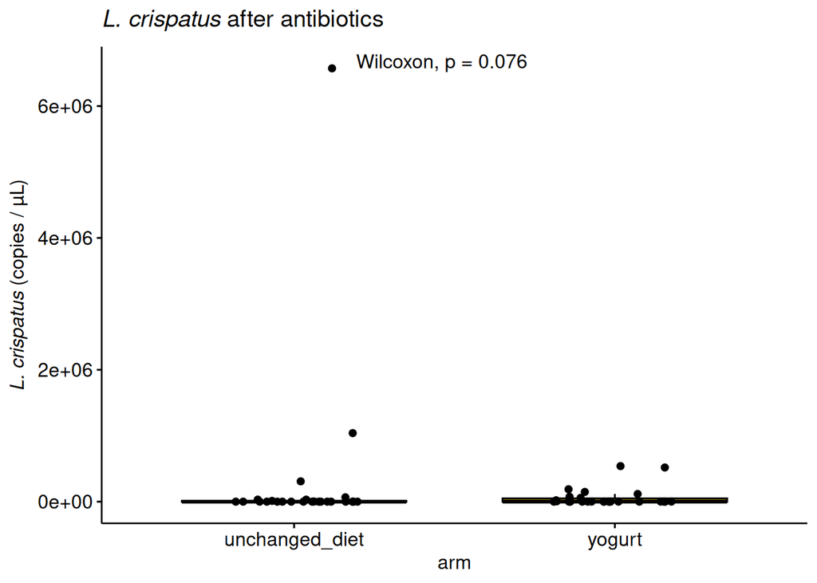

```r
# ── Prepare qPCR data for plotting ─────────────────────────────
qpcr_after <- qpcr |>
  left_join(samples, by = "sample_id") |>
  filter(time_point == "after_antibiotic")

# ── L. crispatus: boxplot by arm ───────────────────────────────
ggboxplot(qpcr_after,
  x = "arm", y = "qpcr_crispatus",
  fill = "arm", palette = "jco",
  add = "jitter"
) +
  stat_compare_means(method = "wilcox.test", label.x = 1.3) +
  labs(
    y = expression(italic("L. crispatus") ~ "(copies / µL)"),
    title = expression(italic("L. crispatus") ~ "after antibiotics")
  ) +
  theme(legend.position = "none")
```

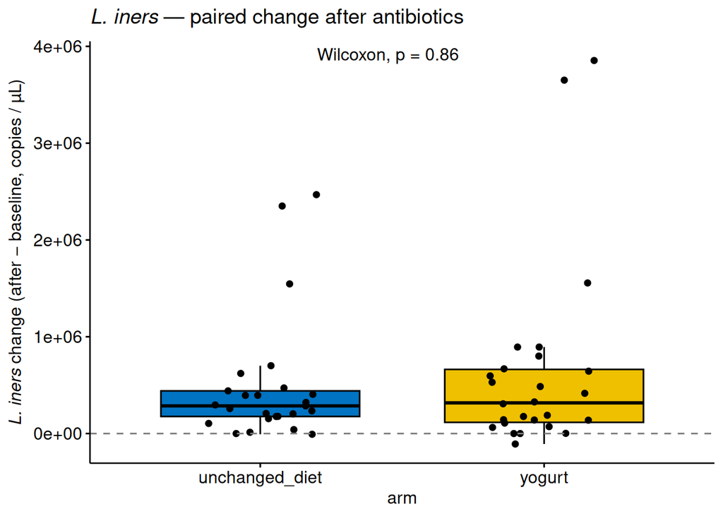

```r
# ── Compute paired change in L. iners ────────────────────────────
iners_change <- qpcr |>
  left_join(samples, by = "sample_id") |>
  filter(time_point %in% c("baseline", "after_antibiotic")) |>
  select(pid, arm, time_point, qpcr_iners) |>
  pivot_wider(names_from = time_point, values_from = qpcr_iners) |>
  mutate(change = after_antibiotic - baseline)

# ── Boxplot of the paired change, by arm ────────────────────────
ggboxplot(iners_change,
  x = "arm", y = "change",
  fill = "arm", palette = "jco",
  add = "jitter"
) +
  stat_compare_means(method = "wilcox.test", label.x = 1.3) +
  labs(
    y = expression(italic("L. iners") ~ "change (after − baseline, copies / µL)"),
    title = expression(italic("L. iners") ~ "— paired change after antibiotics")
  ) +
  geom_hline(yintercept = 0, linetype = "dashed", color = "grey50") +
  theme(legend.position = "none")
```

### B) Paired pre-post — connected line plot

Best for showing change within each arm.

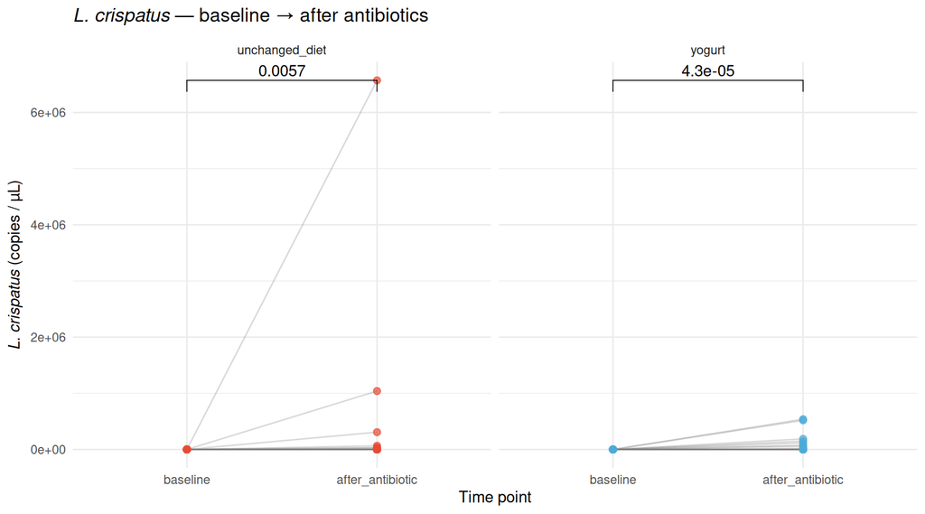

```r
# ── Prepare paired data ────────────────────────────────────────
qpcr_prepost <- qpcr |>
  left_join(samples, by = "sample_id") |>
  filter(time_point %in% c("baseline", "after_antibiotic")) |>
  mutate(time_point = fct_relevel(time_point, "baseline", "after_antibiotic"))

# ── L. crispatus: paired plot ──────────────────────────────────
ggplot(qpcr_prepost, aes(time_point, qpcr_crispatus)) +
  geom_line(aes(group = pid), alpha = 0.3, color = "grey50") +
  geom_point(aes(color = arm), size = 2, alpha = 0.7) +
  facet_wrap(~ arm) +
  scale_color_manual(values = c("unchanged_diet" = "#E64B35", "yogurt" = "#4DABD7")) +
  stat_compare_means(
    method = "wilcox.test",
    paired = TRUE,
    comparisons = list(c("baseline", "after_antibiotic")),
    label.y = max(qpcr_prepost$qpcr_crispatus, na.rm = TRUE) * 0.95
  ) +
  labs(
    x = "Time point",
    y = expression(italic("L. crispatus") ~ "(copies / µL)"),
    title = expression(italic("L. crispatus") ~ "— baseline → after antibiotics")
  ) +
  theme_minimal() +
  theme(legend.position = "none")
```

### C) Total bacteria — boxplot by arm

Compares total bacterial load between the yogurt and unchanged-diet groups after antibiotics. Each point is one participant.

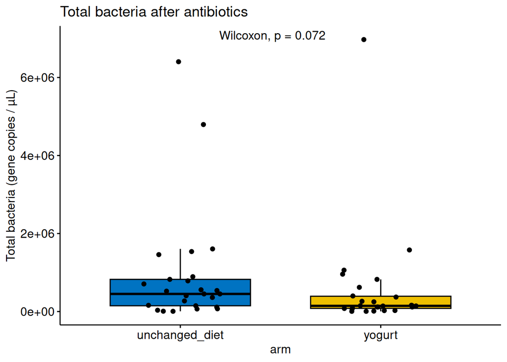

```r
# ── Total bacteria: boxplot by arm ───────────────────────────
ggboxplot(qpcr_after,
  x = "arm", y = "qpcr_bacteria",
  fill = "arm", palette = "jco",
  add = "jitter"
) +
  stat_compare_means(method = "wilcox.test", label.x = 1.3) +
  labs(
    y = "Total bacteria (gene copies / µL)",
    title = "Total bacteria after antibiotics"
  ) +
  theme(legend.position = "none")
```